# Visualização de dados

## Preparação para a aula

- Baixe os dados da pasta exercícios (ou faça pull do seu GitHub)
- Configure o GitHub na sua máquina

– Versionamento -> https://www.curso-r.com/blog/2017-07-17-rstudio-e-github/

– Instruções adicionais de instalação http://r-bio.github.io/git-installation/

- Rode todos os pacotes (usando o macetinho) –> pode baixar o script do exercício 6, que já tem tudo.
- Repositório no GitHub https://github.com/fredbsr/aulas_ENAP/tree/master/CADS2018

## srvyr

## Referências

- Survey http://r-survey.r-forge.r-project.org/survey/
- `srvyr` https://cran.r-project.org/web/packages/srvyr/vignettes/srvyr-vs-survey.html
- Dados amostrais complexos ou aletórias simples (apenas peso amostral)

## Desenho amostral

- `as_survey()`

– ids

– strata

– fpc

– nest

– weights

Pronto, agora trabalhe como se estivesse em um *tibble* `tbl_df` normal, que será um `tbl_svy`

## Este não é um curso de amostragem

- Para maior aprofundamento, leia:

– http://r-survey.r-forge.r-project.org/svybook/

– https://faculty.psau.edu.sa/filedownload/doc-12-pdf-532657fe8ef0e20eada1f34972a4b0dc-original.pdf

– http://r-survey.r-forge.r-project.org/survey/survey-census.pdf

## Exemplo motivador

- Dados de desempenho escolar por escola http://r-survey.r-forge.r-project.org/survey/html/api.html

```r
data(api) #dados de desempenho escolar
```

- `hsg` percentual de pais com graduação
- `stype` é o tipo de escola (Elementary/Middle/High School)

```r
out <- apistrat %>%
  mutate(hs_grad_pct = cut(hsg, c(0, 20, 100), include.lowest = TRUE,
                           labels = c("<20%", "20+%"))) %>%
  group_by(stype, hs_grad_pct) %>%
  summarize(api_diff = weighted.mean(api00 - api99, pw),
            n = n())
```

## Estimativas pontuais

Variável `api-diff`

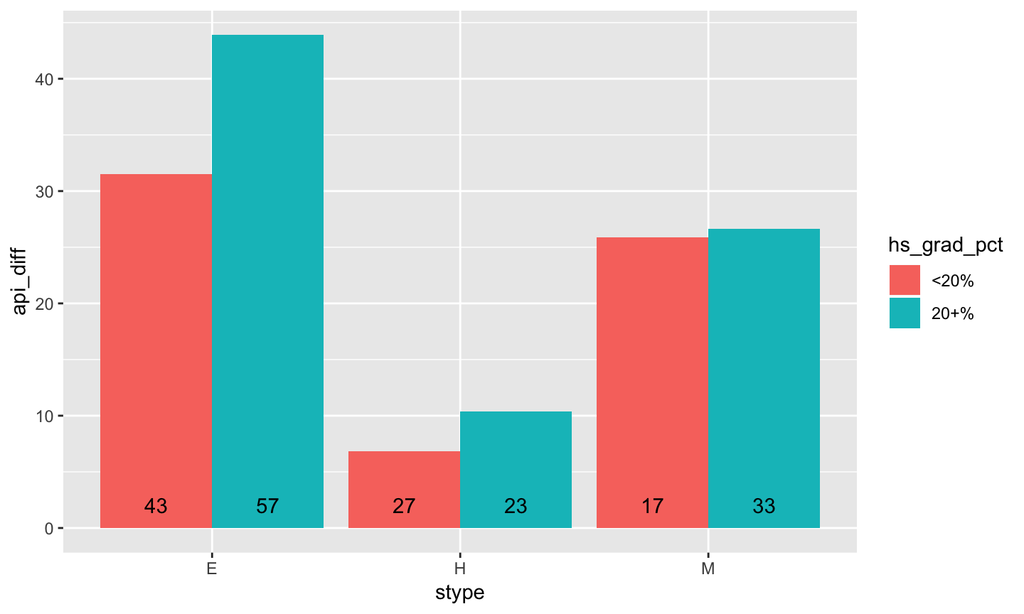

```r
ggplot(data = out, aes(x = stype, y = api_diff, group = hs_grad_pct, fill = hs_grad_pct)) +
  geom_bar(stat = "identity", position = "dodge") +
  geom_text(aes(y = 0, label = n), position = position_dodge(width = 0.9), vjust = -1)
```

## Estimativas intervalares

- `survey_total`
- `survey_mean`
- `survey_median()`
- `survey_ratio()`
- `survey_quantile()`
- Vamos ao live code

## PNAD

- PNADcIBGE https://rpubs.com/BragaDouglas/335574
- ADSFree http://asdfree.com/pesquisa-nacional-por-amostra-de-domicilios-continua-pnadc.html

## Exercício

- Carregue os dados de exemplo do pacote survey `data(api)`
- Qual a proporção de escolas por tipo? (use a variável `stype`)
- Quantas escolas há por tipo? (use a variável `stype`)

## Resolução

```r
strat_design <- apistrat %>%
  as_survey(strata = stype, fpc = fpc, weight  = pw)
```

```r
out <- strat_design %>%
  mutate(hs_grad_pct = cut(hsg, c(0, 20, 100), include.lowest = TRUE,
                           labels = c("<20%", "20+%"))) %>%
  group_by(stype, hs_grad_pct) %>%
  summarize(api_diff = survey_mean(api00 - api99, vartype = "ci"),
            n=unweighted(n()))
```

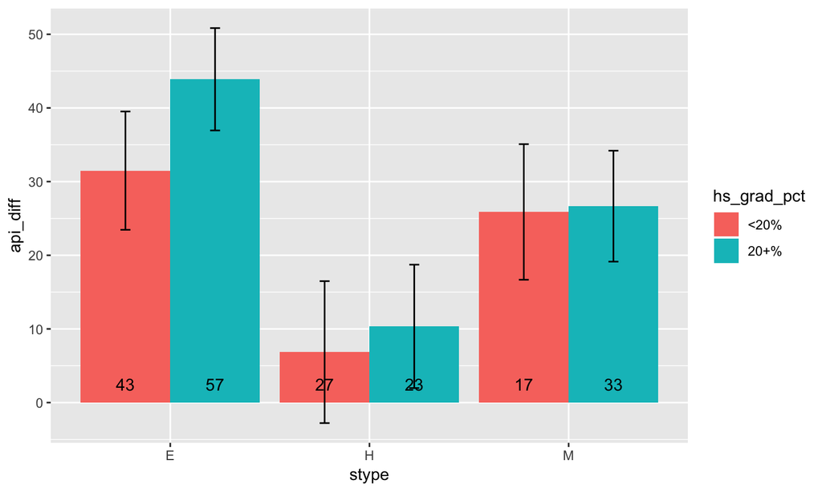

```r
out %>%
  ggplot(aes(x = stype, y = api_diff, group = hs_grad_pct, fill = hs_grad_pct,
                       ymax = api_diff_upp, ymin = api_diff_low)) +
  geom_bar(stat = "identity", position = "dodge") +
  geom_errorbar(position = position_dodge(width = 0.9), width = 0.1) +
  geom_text(aes(y = 0, label = n), position = position_dodge(width = 0.9), vjust = -1)
```

## ggplot

## Princípios

- O que você quer mostrar? https://i1.wp.com/www.tatvic.com/blog/wp-content/uploads/2016/12/Pic_2.png
- Elementos que podem **destacar** ou **confundir** o que você quer mostrar.

## Recursos

- STHDA http://www.sthda.com/english/wiki/be-awesome-in-ggplot2-a-practical-guide-to-be-highly-effective-r-software-and-data-visualization
- R Graph Gallery https://www.r-graph-gallery.com/

## O básico

- Geometrias
- Estéticas
- Escalas (estética)
- Escalas (eixos)
- Temas
- Facet